# ECG数据预处理+DL模型

## 使用WFDB读取数据

### 读取.hea文件

```python
from IPython.display import display
import wfdb
record = wfdb.rdheader('../mit-bih-arrhythmia-database-1.0.0/100')
# display(record.__dict__)
```

### 读取record数据

使用rdrecord函数，该函数的返回值为一个wfdb中定义的record对象。

```
def rdrecord(record_name, sampfrom=0, sampto=None, channels=None,
             physical=True, pb_dir=None, m2s=True, smooth_frames=True,
            ignore_skew=False, return_res=64, force_channels=True,
           channel_names=None, warn_empty=False):
```

常用的重要参数：

- record_name : 储存心电信号的路径;
- sampfrom : 起始位置；
- sampto : 终止位置；
- channels :optional，选择读取某个通道的数据，默认读取全部通道；

```python
from IPython.display import display
import wfdb
record=wfdb.rdrecord('../mit-bih-arrhythmia-database-1.0.0/100')
# display(record.__dict__)
```

几个经常使用的属性值:

1. fs：采样频率；
2. n_sig：信号通道数；
3. sig_len：信号长度；
4. p_signal：模拟信号值，储存形式为ndarray或者是list；
5. d_signal：数字信号值，储存形式为ndarray或者是list。

这些属性都能直接进行访问（如：使用record.fs可以直接读取到采样频率)。

### 读取.art文件

```python
import wfdb
annotation=wfdb.rdann('../mit-bih-arrhythmia-database-1.0.0/100', 'atr')
# display(annotation.__dict__)
```

其中的symbol为心拍注释（包括了正常类型N和各种异常类型）

常见的心拍注释

- 正常心拍 | Normal beat | N | N
- 左束支传导阻滞 | Left bundle branch block beat | LBBB | L
- 右束传导支阻滞 | Right bundle branch block beat | RBBB | R
- 房性早搏 | Atrial premature beat | APB | A
- 室性早搏 | Premature ventricular contraction | PVC | V

## 数据预处理和模型数据集构建

[figure not shown]

### 数据分布统计

```python
import os
type=[]
rootdir = '../mit-bih-arrhythmia-database-1.0.0'           # 设置根路径
files = os.listdir(rootdir) #列出文件夹下所有的目录与文件
name_list=[]
last_name_list=[]         # last_name_list=[100,101,...234]
MLII=[]                 # 用MLII型导联采集的人
type={}                 # 标记及其数量
for file in files:
    if file[0:3] in name_list:   # 根据数据库实际情况调整熟知，这里判断的是每个文件的前三个字符
        continue
    else:
        name_list.append(file[0:3])
for name in name_list:      # 遍历每一个数据文件
    if name[0] not in ['1', '2', '3', '4', '5', '6', '7', '8', '9', '0']:       # 跳过无用的文件
        continue
    last_name_list.append(name)
    record = wfdb.rdrecord(rootdir+'/'+name)  # 读取一条记录（100），不用加扩展名
```

**对每一条数据的MLII导联通道的心拍类型做一个统计**

```python
import pandas as pd

for name in last_name_list:      # 遍历每一个人
    if 'MLII' in record.sig_name:       # 选取一种导联方式（这里以MLII导联为例）
        MLII.append(name)               # 记录下这个文件
    annotation = wfdb.rdann(rootdir+'/'+name, 'atr')  # 然后读取一条记录的atr文件，扩展名atr
    for symbol in annotation.symbol:            # 同时记录下这个文件对应的标记类型
        if symbol in list(type.keys()):
            type[symbol]+=1
        else:
            type[symbol]=1
print('sympbol_name',type)
type_frampe = pd.DataFrame(list(type.values()))
type_pie_data = list(type_frampe.values.reshape(1,-1)[0])
```

```
sympbol_name {'+': 33566, 'N': 1951352, 'A': 66196, 'V': 185380, '~': 16016, '|': 3432, 'Q': 858, '/': 182728, 'f': 25532, 'x': 5018, 'F': 20878, 'j': 5954, 'L': 209950, 'a': 3900, 'J': 2158, 'R': 188734, '[': 156, '!': 12272, ']': 156, 'E': 2756, 'S': 52, '"': 11362, 'e': 416}
```

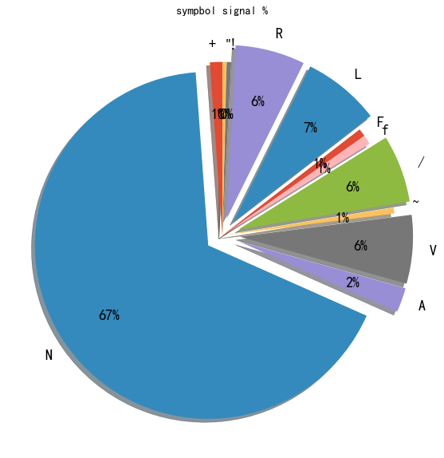

```python
plt.figure(figsize=(10,10))
plt.style.use('ggplot')

label=['+', 'N', 'A', 'V', '~', '/', 'f', 'F', 'L', 'R', '!', '"']
explode = (0, 0.1, 0.1, 0.1, 0, 0.1, 0, 0, 0.1, 0.1, 0, 0)  # only "explode" the 2nd slice (i.e. 'Hogs')

plt.pie([33566, 1951352, 66196, 185380, 16016, 182728, 25532, 20878, 209950, 188734, 12272, 11362],labels=label, autopct='%.0f%%', shadow=True, startangle= 90, textprops={'fontsize': 18}, pctdistance = 0.7, labeldistance = 1.1, explode=explode)
plt.title('sympbol signal %')
```

```python
import pywt
import matplotlib.pyplot as plt

# 测试集在数据集中所占的比例
RATIO = 0.3
```

### 小波变换去噪算法

小波变换有两个变量：尺度a（scale）和平移量 b（translation）

尺度a控制小波函数的伸缩， 平移量b控制小波函数的平移。尺度就对应于频率(反比），平移量b就对应于时间。

$$ \psi_{a, b}(t)=\frac{1}{\sqrt{a}} \psi\left(\frac{t-b}{a}\right) $$

函数x在标度a的子空间上的投影形式

$$ x_{a}(t)=\int_{\mathbb{R}} W T_{\psi}\{x\}(a, b) \cdot \psi_{a, b}(t) d b $$

小波系数公式：

$$ W T_{\psi}\{x\}(a, b)=\left\langle x, \psi_{a, b}\right\rangle=\int_{\mathbb{R}} x(t) \psi_{a, b}(t) d t $$

阈值公式：

$$ \lambda=\frac{median|w|\sqrt{2lnN}}{0.6745} $$

```python
# 小波去噪预处理
def denoise(data):
    # 小波变换
    coeffs = pywt.wavedec(data=data, wavelet='db5', level=9)
    cA9, cD9, cD8, cD7, cD6, cD5, cD4, cD3, cD2, cD1 = coeffs

    # 阈值去噪
    threshold = (np.median(np.abs(cD1)) / 0.6745) * (np.sqrt(2 * np.log(len(cD1))))
    cD1.fill(0)
    cD2.fill(0)
    for i in range(1, len(coeffs) - 2):
        coeffs[i] = pywt.threshold(coeffs[i], threshold)

    # 小波反变换,获取去噪后的信号
    rdata = pywt.waverec(coeffs=coeffs, wavelet='db5')
    return rdata
```

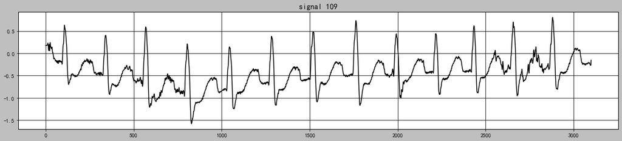

```python
# 109 噪声数据-基线漂移数据
record_109 = wfdb.rdrecord('../mit-bih-arrhythmia-database-1.0.0/109',sampfrom=0, sampto=3100, channel_names=['MLII'])
data_109 = record_109.p_signal.flatten()
plt.figure(figsize=(20, 4))
plt.style.use('grayscale')
plt.plot(list(data_109))
plt.title('signal 109')
```

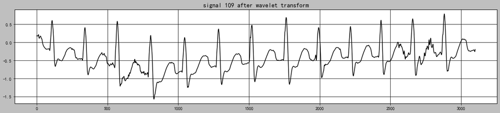

```python
rdata_109 = denoise(data_109)
plt.figure(figsize=(20, 4))
plt.plot(list(rdata_109))
plt.title('signal 109 after wavelet transform')
```

### 模型训练集和测试集建立

```python
 numberSet = ['100', '101', '103', '105', '106', '107', '108', '109', '111', '112', '113', '114', '115',
                 '116', '117', '119', '121', '122', '123', '124', '200', '201', '202', '203', '205', '208',
                 '210', '212', '213', '214', '215', '217', '219', '220', '221', '222', '223', '228', '230',
                 '231', '232', '233', '234']
dataSet = []
lableSet = []
for number in numberSet:
    ecgClassSet = ['N', 'A', 'V', 'L', 'R']

    # 读取心电数据记录
    print("正在读取 " + number + " 号心电数据...")
    record = wfdb.rdrecord('../mit-bih-arrhythmia-database-1.0.0/' + number, channel_names=['MLII'])
    data = record.p_signal.flatten() # flatten是numpy.ndarray.flatten的一个函数，即返回一个一维数组。
    rdata = denoise(data=data) # 小波去噪预处理

    # 获取心电数据记录中R波的位置和对应的标签
    annotation = wfdb.rdann('../mit-bih-arrhythmia-database-1.0.0/' + number, 'atr')
    Rlocation = annotation.sample
    Rclass = annotation.symbol

    # 去掉前后的不稳定数据
    start = 10
    end = 5
    i = start
    j = len(annotation.symbol) - end

    # 因为只选择NAVLR五种心电类型,所以要选出该条记录中所需要的那些带有特定标签的数据,舍弃其余标签的点
    # dataSet在R波前后截取长度为300的数据点
    # lableSet将NAVLR按顺序转换为[0, 1, 2, 3, 4]
    while i < j:
        try:
            lable = ecgClassSet.index(Rclass[i])
            x_train = rdata[Rlocation[i] - 99:Rlocation[i] + 201]
            dataSet.append(x_train)
            lableSet.append(lable)
            i += 1
        except ValueError:
            i += 1
```

```
正在读取 100 号心电数据...
正在读取 101 号心电数据...
正在读取 103 号心电数据...
正在读取 105 号心电数据...
正在读取 106 号心电数据...
正在读取 107 号心电数据...
正在读取 108 号心电数据...
正在读取 109 号心电数据...
正在读取 111 号心电数据...
正在读取 112 号心电数据...
正在读取 113 号心电数据...
正在读取 114 号心电数据...
正在读取 115 号心电数据...
正在读取 116 号心电数据...
正在读取 117 号心电数据...
正在读取 119 号心电数据...
正在读取 121 号心电数据...
正在读取 122 号心电数据...
正在读取 123 号心电数据...
正在读取 124 号心电数据...
正在读取 200 号心电数据...
正在读取 201 号心电数据...
正在读取 202 号心电数据...
正在读取 203 号心电数据...
正在读取 205 号心电数据...
正在读取 208 号心电数据...
正在读取 210 号心电数据...
正在读取 212 号心电数据...
正在读取 213 号心电数据...
正在读取 214 号心电数据...
正在读取 215 号心电数据...
正在读取 217 号心电数据...
正在读取 219 号心电数据...
正在读取 220 号心电数据...
正在读取 221 号心电数据...
正在读取 222 号心电数据...
正在读取 223 号心电数据...
正在读取 228 号心电数据...
正在读取 230 号心电数据...
正在读取 231 号心电数据...
正在读取 232 号心电数据...
正在读取 233 号心电数据...
正在读取 234 号心电数据...
```

```python
# 转numpy数组,打乱顺序
dataSet = np.array(dataSet).reshape(-1, 300)  #不知道300个采样点数据一行的有几行 所以用reshape(-1, 300)
lableSet = np.array(lableSet).reshape(-1, 1)
train_ds = np.hstack((dataSet, lableSet))
np.random.shuffle(train_ds) #shuffle() 方法将序列的所有元素随机排序。
```

```python
train_ds.shape
```

```
(92192, 301)
```

```python
# NAVLR类别个数统计
c0=c1=c2=c3=c4=0
for i in lableSet:
    if i == 0:
        c0+=1
    elif i == 1:
        c1+=1
    elif i == 2:
        c2+=1
    elif i == 3:
        c3+=1
    elif i == 4:
        c4+=1
print('N|0:',c0)
print('A|1:',c1)
print('V|2:',c2)
print('L|3:',c3)
print('R|4:',c4)
```

```
N|0: 71723
A|1: 1950
V|2: 6974
L|3: 6578
R|4: 4967
```

```python
# 数据集及其标签集
X = train_ds[:, :300].reshape(-1, 300, 1) # shape:(92192, 300, 1)
Y = train_ds[:, 300] # shape:(92192,)
```

```python
# 测试集及其标签集
shuffle_index = np.random.permutation(len(X))
test_length = int(RATIO * len(shuffle_index))
test_index = shuffle_index[:test_length]
train_index = shuffle_index[test_length:]
X_test, Y_test = X[test_index], Y[test_index]
X_train, Y_train = X[train_index], Y[train_index]
```

```python
print(X_train.shape)
print(Y_train.shape)
print(X_test.shape)
print(Y_test.shape)
```

```
(64535, 300, 1)
(64535,)
(27657, 300, 1)
(27657,)
```

```python
from pylab import *
mpl.rcParams['font.sans-serif'] = ['SimHei'] # 中文显示
plt.rcParams['axes.unicode_minus']=False #用来正常显示负号
plt.style.use('ggplot')
```

### 五种心律类别可视化

[figure not shown]

```python
plt.figure(figsize=(16, 14))

plt.subplot(3, 3, 1)
list_X0 = list(X_train[1].flatten())
plt.title('正常 N lable %d'%Y_train[1])
plt.plot(list_X0, color='coral')

plt.subplot(3, 3, 2)
list_X1 = list(X_train[130].flatten())
plt.title('房性早搏 A lable %d'%Y_train[303])
plt.plot(list_X1, color='midnightblue')

plt.subplot(3, 3, 3)
list_X2 = list(X_train[0].flatten())
plt.title('室性早搏 V lable %d'%Y_train[0])
plt.plot(list_X2, color='turquoise')

plt.subplot(3, 3, 4)
list_X3 = list(X_train[27065].flatten())
plt.title('左束支传导阻滞 L lable %d'%Y_train[27065])
plt.plot(list_X3, color='seagreen')

plt.subplot(3, 3, 5)
list_X4 = list(X_train[8].flatten())
plt.title('右束传导支阻滞 R lable %d'%Y_train[8])
plt.plot(list_X4, color='yellowgreen')
plt.show()
```

## 深度学习Model Build

### 构建CNN模型

```python
import numpy as np
import seaborn as sns
import tensorflow as tf
from sklearn.metrics import confusion_matrix
```

```python
# 构建CNN模型
def CNN():
    newModel = tf.keras.models.Sequential([
        tf.keras.layers.InputLayer(input_shape=(300, 1)),
        # 第一个卷积层, 4 个 21x1 卷积核
        tf.keras.layers.Conv1D(filters=4, kernel_size=21, strides=1, padding='SAME', activation='relu'),
        # 第一个池化层, 最大池化,4 个 3x1 卷积核, 步长为 2
        tf.keras.layers.MaxPool1D(pool_size=3, strides=2, padding='SAME'),
        # 第二个卷积层, 16 个 23x1 卷积核
        tf.keras.layers.Conv1D(filters=16, kernel_size=23, strides=1, padding='SAME', activation='relu'),
        # 第二个池化层, 最大池化,4 个 3x1 卷积核, 步长为 2
        tf.keras.layers.MaxPool1D(pool_size=3, strides=2, padding='SAME'),
        # 第三个卷积层, 32 个 25x1 卷积核
        tf.keras.layers.Conv1D(filters=32, kernel_size=25, strides=1, padding='SAME', activation='relu'),
        # 第三个池化层, 平均池化,4 个 3x1 卷积核, 步长为 2
        tf.keras.layers.AvgPool1D(pool_size=3, strides=2, padding='SAME'),
        # 第四个卷积层, 64 个 27x1 卷积核
        tf.keras.layers.Conv1D(filters=64, kernel_size=27, strides=1, padding='SAME', activation='relu'),
        # 打平层,方便全连接层处理
        tf.keras.layers.Flatten(),
        # 全连接层,128 个节点
        tf.keras.layers.Dense(128, activation='relu'),
        # Dropout层,dropout = 0.2
        tf.keras.layers.Dropout(rate=0.2),
        # 全连接层,5 个节点
        tf.keras.layers.Dense(5, activation='softmax')
    ])
    return newModel
```

```python
# 项目目录
project_path = "./"
# 日志目录
log_dir = project_path + "CNN_logs\\" + datetime.datetime.now().strftime("%Y%m%d-%H%M%S")
# 模型目录
model_path = project_path + "ECG_CNN.h5"

# 构建CNN模型
model = CNN()
model.compile(optimizer='adam',
              loss='sparse_categorical_crossentropy', # 多类的对数损失
              metrics=['accuracy'])
model.summary()
# 定义TensorBoard对象
tensorboard_callback = tf.keras.callbacks.TensorBoard(log_dir=log_dir, histogram_freq=1)
# 训练与验证
model.fit(X_train, Y_train, epochs=30,
          batch_size=128,
          validation_split=RATIO,
          callbacks=[tensorboard_callback])
model.save(filepath=model_path)
```

```
Model: "sequential"
_________________________________________________________________
Layer (type)                 Output Shape              Param #
=================================================================
conv1d (Conv1D)              (None, 300, 4)            88
_________________________________________________________________
max_pooling1d (MaxPooling1D) (None, 150, 4)            0
_________________________________________________________________
conv1d_1 (Conv1D)            (None, 150, 16)           1488
_________________________________________________________________
max_pooling1d_1 (MaxPooling1 (None, 75, 16)            0
_________________________________________________________________
conv1d_2 (Conv1D)            (None, 75, 32)            12832
_________________________________________________________________
average_pooling1d (AveragePo (None, 38, 32)            0
_________________________________________________________________
conv1d_3 (Conv1D)            (None, 38, 64)            55360
_________________________________________________________________
flatten (Flatten)            (None, 2432)              0
_________________________________________________________________
dense (Dense)                (None, 128)               311424
_________________________________________________________________
dropout (Dropout)            (None, 128)               0
_________________________________________________________________
dense_1 (Dense)              (None, 5)                 645
=================================================================
Total params: 381,837
Trainable params: 381,837
Non-trainable params: 0
_________________________________________________________________
```

```python
# 预测
Y_pred = model.predict_classes(X_test)
```

#### 机器学习分类模型常用评价指标有Accuracy, Precision, Recall和F1-score

$$ \text { Accuracy }=\frac{T P+T N}{T P+T N+F P+F N} $$$$ \text { Precision }=\frac{T P}{T P+F P} $$$$ \text { Recall }=\frac{T P}{T P+F N} $$$$ F 1-\text { score }=\frac{2 \times \text { Precision } \times \text { Recall }}{\text { Precision }+\text { Recall }} $$

**Macro-average方法**

- 该方法最简单，直接将不同类别的评估指标（Precision/ Recall/ F1-score）加起来求平均，给所有类别相同的权重。该方法能够平等看待每个类别，但是它的值会受稀有类别影响。

**Weighted-average方法**

- 该方法给不同类别不同权重（权重根据该类别的真实分布比例确定），每个类别乘权重后再进行相加。该方法考虑了类别不平衡情况，它的值更容易受到常见类（majority class）的影响。

**Micro-average方法**

- 该方法把每个类别的TP, FP, FN先相加之后，在根据二分类的公式进行计算。

```python
from sklearn.metrics import accuracy_score
from sklearn.metrics import precision_score
from sklearn.metrics import f1_score
from sklearn.metrics import recall_score

Y_pred.shape
Y_test.shape
# 计算精确度
# correct_prediction = np.equal(Y_pred, Y_test)
# print(np.mean(correct_prediction))   <==> accuracy_score()

print('Accuracy:', accuracy_score(list(Y_pred), list(Y_test)))
# print('Precision:', precision_score(list(Y_pred), list(Y_test), average='weighted'))
# print('Recall:', recall_score(list(Y_pred), list(Y_test), average='weighted'))
# print('F1_score:', f1_score(list(Y_pred), list(Y_test), average='weighted'))

print('------Weighted------')
print('Weighted precision', precision_score(list(Y_pred), list(Y_test), average='weighted'))
print('Weighted recall', recall_score(list(Y_pred), list(Y_test), average='weighted'))
print('Weighted f1-score', f1_score(list(Y_pred), list(Y_test), average='weighted'))
print('------Macro------')
print('Macro precision', precision_score(list(Y_pred), list(Y_test), average='macro'))
print('Macro recall', recall_score(list(Y_pred), list(Y_test), average='macro'))
print('Macro f1-score', f1_score(list(Y_pred), list(Y_test), average='macro'))
print('------Micro------')
print('Micro precision', precision_score(list(Y_pred), list(Y_test), average='micro'))
print('Micro recall', recall_score(list(Y_pred), list(Y_test), average='micro'))
print('Micro f1-score', f1_score(list(Y_pred), list(Y_test), average='micro'))
```

```
Accuracy: 0.9934193874968362
------Weighted------
Weighted precision 0.993660434452819
Weighted recall 0.9934193874968362
Weighted f1-score 0.9934932765602341
------Macro------
Macro precision 0.9692940889562662
Macro recall 0.9891487280946443
Macro f1-score 0.9789097544826614
------Micro------
Micro precision 0.9934193874968362
Micro recall 0.9934193874968362
Micro f1-score 0.9934193874968362
```

[figure not shown]

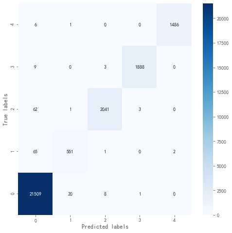

```
'\nN|0: 71723\nA|1: 1950\nV|2: 6974\nL|3: 6578\nR|4: 4967\n'
```

```python
# 混淆矩阵
con_mat = confusion_matrix(Y_test, Y_pred)

# 绘图
plt.figure(figsize=(8, 8))
sns.heatmap(con_mat, annot=True, fmt='.20g', cmap='Blues')
plt.ylim(0, 5)
plt.xlabel('Predicted labels')
plt.ylabel('True labels')
plt.show()
"""
N|0: 71723
A|1: 1950
V|2: 6974
L|3: 6578
R|4: 4967
"""
```

### 构建CNN+LSTM模型

```python
def CNN_LSTM():
    newmodel = tf.keras.models.Sequential([
        tf.keras.layers.Conv1D(filters=128, kernel_size=20, strides=3, padding='same',activation=tf.nn.relu),
        tf.keras.layers.BatchNormalization(),
        tf.keras.layers.MaxPool1D(pool_size=2, strides=3),
        tf.keras.layers.Conv1D(filters=32, kernel_size=7, strides=1, padding='same', activation=tf.nn.relu),
        tf.keras.layers.BatchNormalization(),
        tf.keras.layers.MaxPool1D(pool_size=2, strides=2),
        tf.keras.layers.Conv1D(filters=32, kernel_size=10, strides=1, padding='same', activation=tf.nn.relu),
        # tf.keras.layers.Conv1D(filters=128, kernel_size=5, strides=2, padding='same', activation=tf.nn.relu),
        tf.keras.layers.MaxPool1D(pool_size=2, strides=2),
        # tf.keras.layers.Conv1D(filters=512, kernel_size=5, strides=1, padding='same', activation=tf.nn.relu),
        # tf.keras.layers.Conv1D(filters=128, kernel_size=3, strides=1, padding='same', activation=tf.nn.relu),
        tf.keras.layers.LSTM(10),
        tf.keras.layers.Flatten(),
        # tf.keras.layers.Dense(units=512, activation=tf.nn.relu),
        tf.keras.layers.Dropout(rate=0.1),
        tf.keras.layers.Dense(units=20, activation=tf.nn.relu),
        tf.keras.layers.Dense(units=10, activation=tf.nn.relu),
        tf.keras.layers.Dense(units=7, activation=tf.nn.softmax)
    ])
    return newmodel
```

```python
# 日志目录
log_dir = project_path + "CNN_LSTM_logs\\" + datetime.datetime.now().strftime("%Y%m%d-%H%M%S")
# 模型目录
model_path = project_path + "ECG_CNN_LSTM.h5"

# 构建CNN_LSTM模型
CNN_LSTM_model = CNN_LSTM()

CNN_LSTM_model.compile(optimizer='adam',
              loss='sparse_categorical_crossentropy', # 多类的对数损失
              metrics=['accuracy'])

# CNN_LSTM_model.summary()
# 定义TensorBoard对象
tensorboard_callback = tf.keras.callbacks.TensorBoard(log_dir=log_dir, histogram_freq=1)
# 训练与验证
CNN_LSTM_model.fit(X_train, Y_train, epochs=30,
          batch_size=128,
          validation_split=RATIO,
          callbacks=[tensorboard_callback])
CNN_LSTM_model.save(filepath=model_path)
```

```python
# 预测
CNN_LSTM_Y_pred = CNN_LSTM_model.predict_classes(X_test)
```

```python
print('Accuracy:', accuracy_score(list(CNN_LSTM_Y_pred), list(Y_test)))

print('------Weighted------')
print('Weighted precision', precision_score(list(CNN_LSTM_Y_pred), list(Y_test), average='weighted'))
print('Weighted recall', recall_score(list(CNN_LSTM_Y_pred), list(Y_test), average='weighted'))
print('Weighted f1-score', f1_score(list(CNN_LSTM_Y_pred), list(Y_test), average='weighted'))
print('------Macro------')
print('Macro precision', precision_score(list(CNN_LSTM_Y_pred), list(Y_test), average='macro'))
print('Macro recall', recall_score(list(CNN_LSTM_Y_pred), list(Y_test), average='macro'))
print('Macro f1-score', f1_score(list(CNN_LSTM_Y_pred), list(Y_test), average='macro'))
print('------Micro------')
print('Micro precision', precision_score(list(CNN_LSTM_Y_pred), list(Y_test), average='micro'))
print('Micro recall', recall_score(list(CNN_LSTM_Y_pred), list(Y_test), average='micro'))
print('Micro f1-score', f1_score(list(CNN_LSTM_Y_pred), list(Y_test), average='micro'))
```

```
Accuracy: 0.9915753697074882
------Weighted------
Weighted precision 0.9923193387653683
Weighted recall 0.9915753697074882
Weighted f1-score 0.9917894548525673
------Macro------
Macro precision 0.9549331419148714
Macro recall 0.989562018732947
Macro f1-score 0.970635548004432
------Micro------
Micro precision 0.9915753697074882
Micro recall 0.9915753697074882
Micro f1-score 0.9915753697074882
```

[figure not shown]

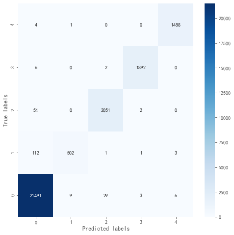

```python
# 混淆矩阵
con_mat = confusion_matrix(Y_test, CNN_LSTM_Y_pred)

# 绘图
plt.figure(figsize=(8, 8))
sns.heatmap(con_mat, annot=True, fmt='.20g', cmap='Blues')
plt.ylim(0, 5)
plt.xlabel('Predicted labels')
plt.ylabel('True labels')
plt.show()
```